# Basic Tools For Forecasting

Week 3 R-lab  
(Lagging a Time series& Computing Successive Differences in R)  
Zhaohu(Jonathan) Fan

05/27/2021

# Transformations

Summary of Dulles Excel

```r
# Step 0: Load R packages (R Environment Preparation)
# - Load the required packages to execute the assignment.
# - Make sure the following packages are installed on your computer.
library(zoo)
library(readxl)
library(forecast)
library(quantmod)
library(ggplot2)
# Set working directory
setwd("C:/Users/fanzh/OneDrive - University of Cincinnati/UC_couse/000_Teaching_4090_SS21/Labs/Week3")
Dulles <- read_xlsx("Dulles.xlsx")
summary(Dulles)
```

```
##      Year           Passengers (000s)
##  Length:53          Min.   :  640.5
##  Class :character   1st Qu.: 2083.1
##  Mode  :character   Median : 8946.6
##                     Mean   : 8455.9
##                     3rd Qu.:14393.0
##                     Max.   :22129.0
```

# Transformations

$\color{red}{\text{Dulles, we have a problem!}}$

Time series plot of Dulles

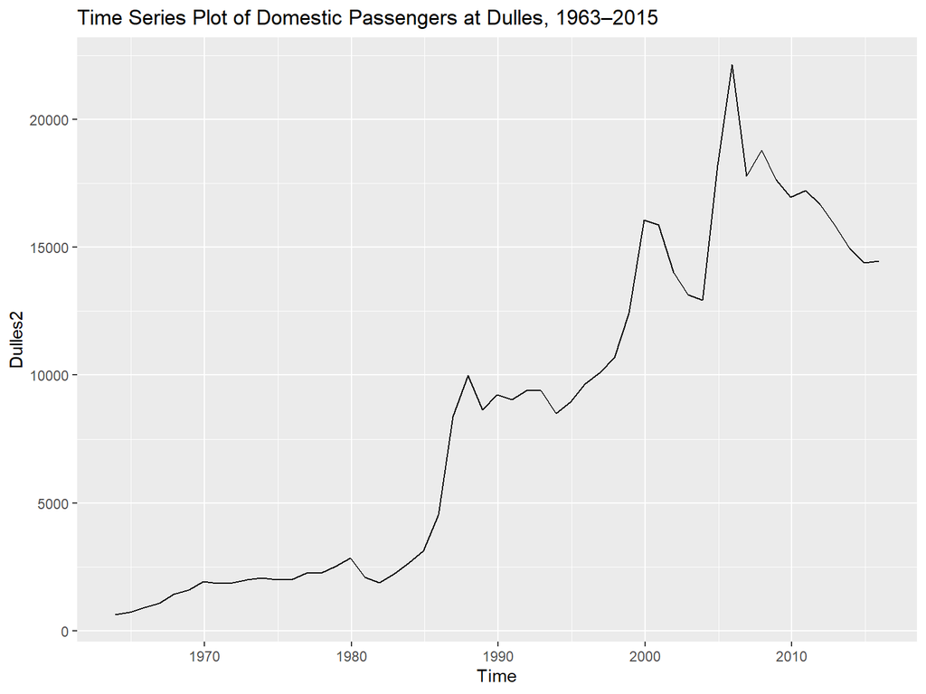

```r
#library(ggplot2); library(ggfortify); library(zoo)
Dulles2 <- ts(data = Dulles$`Passengers (000s)`, start = as.yearmon("1963-12"), frequency = 1)
autoplot(Dulles2,main = "Time Series Plot of Domestic Passengers at Dulles, 1963–2015")
```

# Transformations: Differences

Basic R Syntax of diff():

```r
 # diff(x)
```

Definition of diff():

The diff function computes the difference between pairs of consecutive elements of a numeric vector.

In R we can use the `diff(x,lag,diff)` function for differencing a time series, which requires 3 arguments:

```
- x (the data)
- lag (the lag at which to difference)
- differences/diff (the order of differencing).
```

Note: The second argument is the lag, which is the number of periods, and the third argument is differences, which is the order of the difference (e.g. how many times diff() is called).

# **Let’s practice!**

```r
X<- data.frame(Date=1:5, Dulles_2=c(1,4,10,20,35))
head(X,7)
```

```
##   Date Dulles_2
## 1    1        1
## 2    2        4
## 3    3       10
## 4    4       20
## 5    5       35
```

> How to obtain a first order difference of `X$Dulles_2` in R?